# Predictive regressions: comparing methods

# Packages & parameters

We start by loading the required packages & functions.

```r
rm(list = ls())
library(tidyverse)
library(Rcpp)
library(mvtnorm)
library(reshape2)
library(latex2exp)
library(cowplot)
sourceCpp("c_functions.cpp")
source("R_functions.R")
```

Then, we set some **default parameter** values. **Note**: because T is reserved in R, we use TT instead.

```r
k   <- 12
TT  <- 36          # TT = number of observations
a_x <- 0           # Constant in the AR process
a_y <- 0           # Constant in the AR process
r_x <- 0.9         # rho_x
r_y <- 0.7         # rho_y
s_x <- 0.2         # sigma_x
s_y <- 0.4         # sigma_y
cor <- 0           # Correlation between innovations e_y and e_x
n_sim <- 10^5      # Number of simulations
n_points <- 10^3   # Number of discretization points in the approximation of the integral
STOP <- 10^3       # Point where the discretization stops
```

# Testing the functions

All functions were coded both in **R** and **C**. The C versions were only faster for the autoregressive simulations. However, the matrix multiplications in the large dimensional simulations made the C (or C++ in Armadillo) code slower. Below, we test the following:

- **Process**: relying on the function that simulates correlated bivariate AR(1) processes (in C): **quad_err_C_2d**
- **Multivariate**: relying on the function that simulates vector z using the large covariance matrix (in R): **MSE_simulation**
- **Integral**: relying on the function that uses numerical integration to compute the MSE: **MSE_integral**

In the first function, processes are allowed to have a drift, but this drift does not impact the MSE, so we set it to zero.

We use tictoc to compute running times.

```r
tictoc::tic()
quad_err_C_2d2(a_x, a_y, r_x, r_y, s_x, s_y, cor, TT, k, n_sim)
```

```
[1] 0.4205584 0.3866333
```

```r
tictoc::toc()
```

```
2.547 sec elapsed
```

```r
tictoc::tic()
MSE_simulation(a_x, a_y, r_x, r_y, s_x, s_y, cor, TT, k, n_sim)
```

```
[1] 0.4211911 0.3793136
```

```r
tictoc::toc()
```

```
10.789 sec elapsed
```

```r
tictoc::tic()
MSE_integral_ind(r_x, r_y, s_y, TT, k, n_points, STOP)
```

```
[1] 0.4217557
```

```r
tictoc::toc()
```

```
0.454 sec elapsed
```

```r
tictoc::tic()
MSE_integral(r_x, r_y, s_y, cor, TT, k, n_points, STOP)
```

```
[1] 0.4217697
```

```r
tictoc::toc()
```

```
3.637 sec elapsed
```

Even with 100,000 simulations, the values are already close.

# First study

The first step is to evaluate the **accuracy** of the methods and quantify how long they take.  
The C functions were not designed to take vectors parameter values, thus we resort to ugly loops, though functional programming would be more elegant (see the sensitivity analysis below). One important reason why a loop is convenient is that it’s easy to reset the (pseudo-)random number generator.  
This is not costly computationally because the number of iterations is small.  
Nevertheless, the loop below is quite **time-consuming** (a few hours on a 2019 MacBook Pro).

```r
n <- 1000*2^(0:12)
stop <- 100 * round(log(n))
val_AR_sim <- 0
val_S_sim <- 0
val_integral_ind <- 0
var_AR_sim <- 0
var_S_sim <- 0
cpu_AR_sim <- 0
cpu_S_sim <- 0
cpu_integral_ind <- 0
for(i in 1:length(n)){
    set.seed(42)
    tictoc::tic()
    tmp <- quad_err_C_2d2(a_x, a_y, r_x, r_y, s_x, s_y, cor, TT, k, n[i])
    val_AR_sim[i] <- tmp[1]
    var_AR_sim[i] <- tmp[2]
    z <- tictoc::toc(quiet = T)
    cpu_AR_sim[i] <- z$toc - z$tic

    set.seed(42)
    tictoc::tic()
    tmp <- MSE_simulation(a_x, a_y, r_x, r_y, s_x, s_y, cor, TT, k, n[i])
    val_S_sim[i] <- tmp[1]
    var_S_sim[i] <- tmp[2]
    z <- tictoc::toc(quiet = T)
    cpu_S_sim[i] <- z$toc - z$tic

    set.seed(42)
    tictoc::tic()
    val_integral_ind[i] <- MSE_integral_ind(r_x, r_y, s_y, TT, k, n[i], STOP = stop[i])
    z <- tictoc::toc(quiet = T)
    cpu_integral_ind[i] <- z$toc - z$tic
}

val <- data.frame(n, val_AR_sim, val_S_sim, val_integral_ind) %>%
    pivot_longer(-n, names_to = "type", values_to = "value") %>%
    mutate(indicator = "MSE",
           type = substr(type, 5, 9))
save(val, file="values.RData")

cpu <- data.frame(n, cpu_AR_sim, cpu_S_sim, cpu_integral_ind) %>%
    pivot_longer(-n, names_to = "type", values_to = "value") %>%
    mutate(indicator = "CPU")
save(cpu, file = "cpu.RData")

CI <- data.frame(n, var_AR_sim, var_S_sim) %>%
    pivot_longer(-n, names_to = "type", values_to = "value") %>%
    mutate(indicator = "CI",
           type = substr(type, 5, 9),
           value = 1.96 * sqrt(value/n)) # Width of confidence interval
save(var, file = "CI.RData")
```

Then, we wrangle the results and plot them.  
We start with the **raw MSE** values.

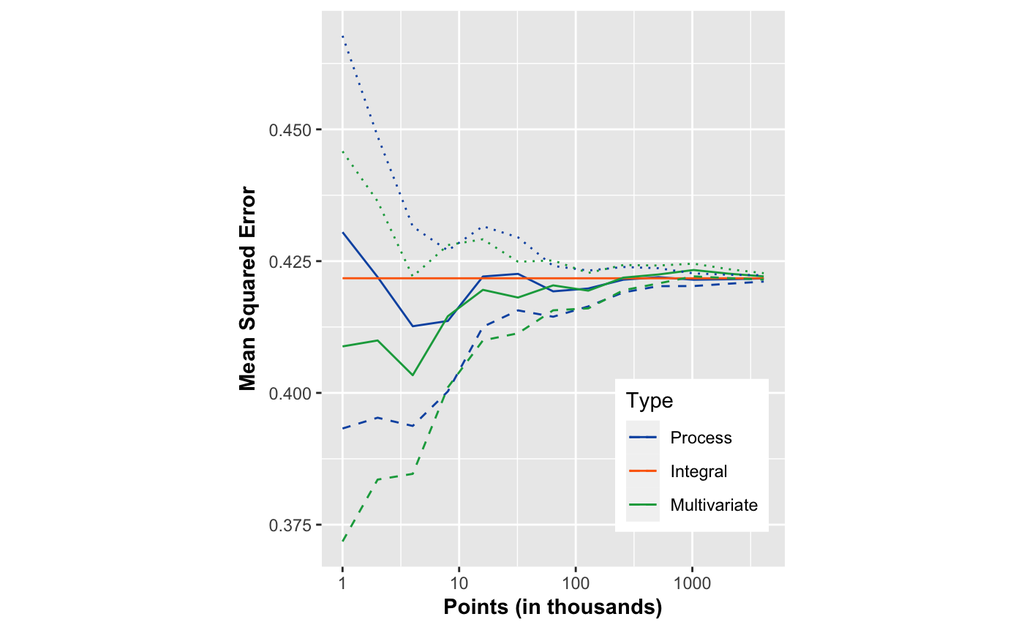

```r
data_g <- bind_rows(val, CI) %>%
    pivot_wider(names_from = "indicator", values_from = "value") %>%
    mutate(lower = MSE - CI, upper = MSE + CI) %>%
    pivot_longer(3:6, names_to = "indicator", values_to = "value")
plot_MSE_n <- data_g %>%
    ggplot(aes(x = n/1000, y = value, color = type)) +
    geom_line(data = data_g %>% filter(indicator == "MSE")) +
    geom_line(data = data_g %>% filter(indicator == "lower"), linetype = 2) +
    geom_line(data = data_g %>% filter(indicator == "upper"), linetype = 3) +
    xlab(TeX("\\textbf{Points (in thousands)}")) + ylab(TeX("\\textbf{Mean Squared Error}")) +
    #scale_color_viridis(option="inferno", begin = 0.4, end = 0.9, discrete = TRUE)
    scale_color_manual(name = "Type",
                       labels = c("Process", "Integral", "Multivariate"),
                       values = c("#0B56B0", "#FD6909", "#12A74C")) +
    scale_x_log10() +
    theme(aspect.ratio = 1.2, legend.position = c(0.8, 0.2))
plot_MSE_n
```

We see that **Monte-Carlo** simulations, as expected, yield values that oscillate a lot. The speed of convergence is proportional to $n^{-1/2}$, so in our case, the error has an order of magnitude of $10^{-3}$, which is what we observe.

Next, we turn to **computation times**.

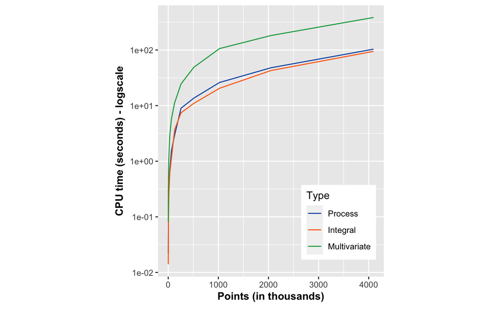

```r
plot_CPU_n <- cpu %>%
    ggplot(aes(x = n/1000, y = value, color = type)) + geom_line() +
    xlab(TeX("\\textbf{Points (in thousands)}")) + ylab(TeX("\\textbf{CPU time (seconds) - logscale}")) +
    scale_y_log10() +
    scale_color_manual(name = "Type",
                       labels = c("Process", "Integral", "Multivariate"),
                       values = c("#0B56B0", "#FD6909", "#12A74C")) +
    theme(aspect.ratio = 1.2, legend.position = c(0.8, 0.2))
plot_CPU_n
```

Below, in order to save time, we discard the slowest method.

# Save both plots together

```
Removed 13 row(s) containing missing values (geom_path).Removed 13 row(s) containing missing values (geom_path).
```

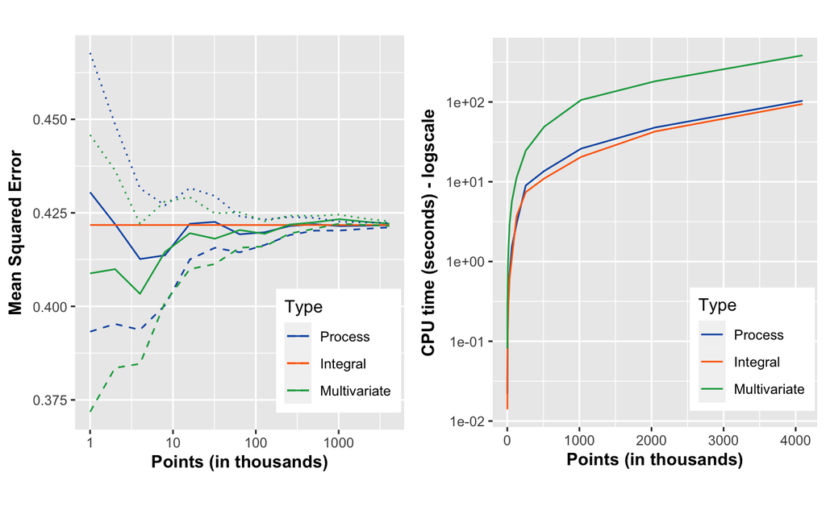

```r
plot_grid(plot_MSE_n, plot_CPU_n, ncol = 2, nrow = 1)
```

```r
#ggsave(paste(folder, "comparison.pdf", sep='/'))
```

# Impact of T

Next, we switch to other values of T. It’s interesting to see what happens when the sample size augments.  
Again, we resort to a loop.

```r
TTT <- seq(5,100,5)
value_AR_sim <- 0
value_integral_ind <- 0
cpu_AR_sim <- 0
cpu_integral_ind <- 0
for(i in 1:length(TTT)){
    tictoc::tic()
    value_AR_sim[i] <- quad_err_C_2d2(a_x, a_y, r_x, r_y, s_x, s_y, cor, TTT[i], k, n_sim)
    z <- tictoc::toc()
    cpu_AR_sim[i] <- z$toc - z$tic

    tictoc::tic()
    value_integral_ind[i] <- MSE_integral_ind(r_x, r_y, s_y, TTT[i], k, n_points, 100 * round(log(n_points)) )
    z <- tictoc::toc()
    cpu_integral_ind[i] <- z$toc - z$tic
}
```

[output not shown]

```
1.083 sec elapsed
0.002 sec elapsed
```

[output not shown]

```
1.289 sec elapsed
0.003 sec elapsed
```

[output not shown]

```
1.437 sec elapsed
0.005 sec elapsed
```

[output not shown]

```
1.883 sec elapsed
0.008 sec elapsed
```

[output not shown]

```
1.822 sec elapsed
0.011 sec elapsed
```

[output not shown]

```
2.07 sec elapsed
0.012 sec elapsed
```

[output not shown]

```
2.871 sec elapsed
0.023 sec elapsed
```

[output not shown]

```
3.061 sec elapsed
0.014 sec elapsed
```

[output not shown]

```
3.023 sec elapsed
0.019 sec elapsed
```

[output not shown]

```
3.027 sec elapsed
0.022 sec elapsed
```

[output not shown]

```
3.448 sec elapsed
0.029 sec elapsed
```

[output not shown]

```
3.705 sec elapsed
0.035 sec elapsed
```

[output not shown]

```
3.848 sec elapsed
0.041 sec elapsed
```

[output not shown]

```
4.263 sec elapsed
0.046 sec elapsed
```

[output not shown]

```
4.03 sec elapsed
0.053 sec elapsed
```

[output not shown]

```
4.778 sec elapsed
0.064 sec elapsed
```

[output not shown]

```
4.997 sec elapsed
0.069 sec elapsed
```

[output not shown]

```
4.963 sec elapsed
0.08 sec elapsed
```

[output not shown]

```
5.318 sec elapsed
0.086 sec elapsed
```

[output not shown]

```
5.559 sec elapsed
0.158 sec elapsed
```

```r
values_TT <- data.frame(TTT, value_AR_sim, value_integral_ind) %>%
    pivot_longer(-TTT, names_to = "type", values_to = "value")
save(values_TT, file = "values_TT.RData")

cpu_TT <- data.frame(TTT, cpu_AR_sim, cpu_integral_ind) %>%
    pivot_longer(-TTT, names_to = "type", values_to = "value")
save(cpu_TT, file = "cpu_TT.RData")
```

Then we analyze the results.

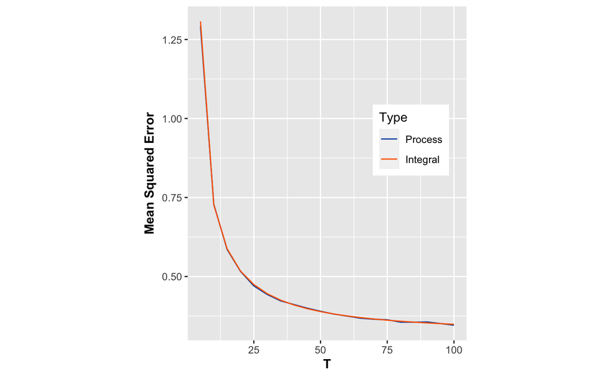

```r
plot_MSE_T <- values_TT %>%
    ggplot(aes(x = TTT, y = value, color = type)) + geom_line() +
    xlab(TeX("\\textbf{T}")) + ylab(TeX("\\textbf{Mean Squared Error}")) +
    #scale_color_viridis(option="inferno", begin = 0.4, end = 0.9, discrete = TRUE)
    scale_color_manual(name = "Type",
                       labels = c("Process", "Integral"),
                       values = c("#0B56B0", "#FD6909")) +
    theme(aspect.ratio = 1.2, legend.position = c(0.8, 0.6))
plot_MSE_T
```

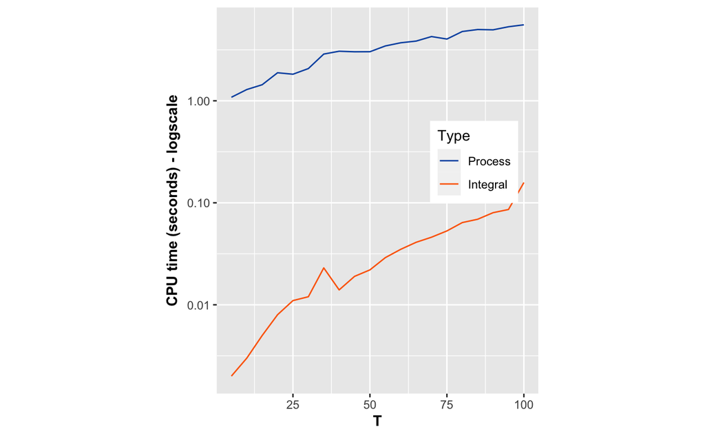

```r
plot_CPU_T <- cpu_TT %>%
    ggplot(aes(x = TTT, y = value, color = type)) + geom_line() +
    xlab(TeX("\\textbf{T}")) + ylab(TeX("\\textbf{CPU time (seconds) - logscale}")) +
    scale_y_log10() +
    scale_color_manual(name = "Type",
                       labels = c("Process", "Integral"),
                       values = c("#0B56B0", "#FD6909")) +
    theme(aspect.ratio = 1.2, legend.position = c(0.8, 0.6))
plot_CPU_T
```

```
Removed 13 row(s) containing missing values (geom_path).Removed 13 row(s) containing missing values (geom_path).
```

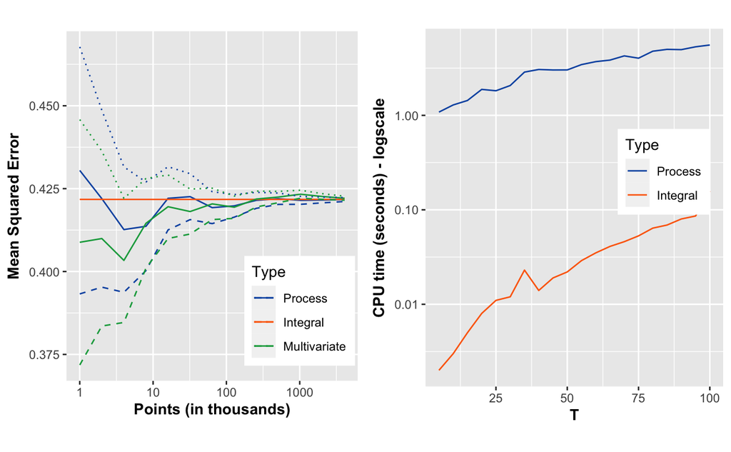

```r
plot_grid(plot_MSE_n, plot_CPU_T, ncol = 2, nrow = 1)
```

```r
#ggsave("comparison_09.pdf")
```

# First sensitivity analysis

Below, we resort to a bit of **functional programming**. This nice trick allows to bypass the use of ugly loops.

```r
r <- c(0.1, 0.6, 0.9, 0.93, 0.95, 0.97, 0.99)
TT <- seq(6,120,3)
pars <- expand.grid(r, TT)
r <- pars[,1]
TT <- pars[,2]

MSE_univar <- function(r, TT){
    MSE_integral_ind(r, r, 1, TT, k, n_points, 100 * round(log(n_points)) )
}

results_sensi_uni <- pmap(list(r, TT), MSE_univar) %>%
    melt() %>% bind_cols(pars)
colnames(results_sensi_uni) <- c("MSE", "index", "r", "TT")
save(results_sensi_uni, file =  "results_sensi.RData")
```

Finally, we plot.

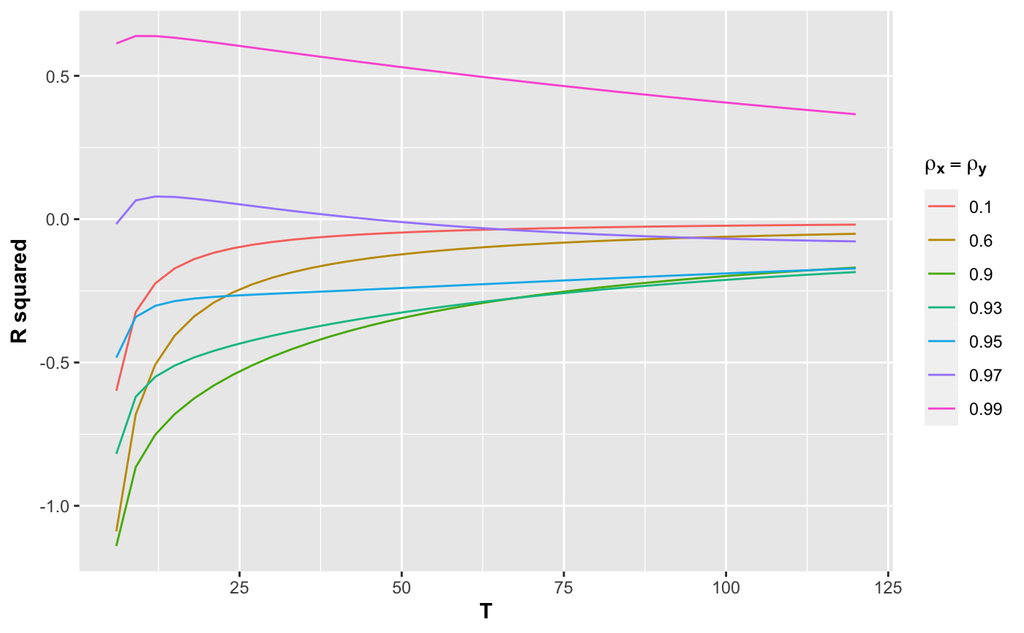

```r
results_sensi_uni %>%
    mutate(R2 = 1-(1-r^2)*MSE) %>%
    ggplot(aes(x = TT, y = R2, color = as.factor(r))) +
    geom_line() +
    labs(color = TeX("$\\textbf{\\rho_x=\\rho_y$}")) +
    xlab(TeX("\\textbf{T}")) + ylab(TeX("\\textbf{R squared}")) #+
    #theme(legend.position = c(1, 0.4)) #+
    #guides(col = guide_legend(ncol = 2))
ggsave("sensi_09.pdf", width = 6, height = 4)
```